# Pilot study APEROL: questionnaire data

Mandy Klatt, Gregor Kachel and Anne Deiglmayr

2021-02-02

# Short Summary

This report provides a summary of the questionnaire data of the first pilot APEROL. The aim was to explore connections between the visual attention of the teacher and students’ in-class experience of the teachers’ “withitness”. The study was conducted as a lab study with simulated scripted mini-lessons (10min per lesson). Data was collected from N = 8 teachers in 2 sessions.

In each session, one subject took the role of teacher, while the other teachers acted as the class. After each lesson, the subjects answered items on classroom management, especially on the teacher’s behaviour, using validated questionnaires. An external observer also answered a questionnaire. In addition, the teacher was asked to give a self-assessment on his/her classroom management.

### Data collection

For the pilot study, we collected questionnaire data from N = 8 subjects in 2 sessions. The questionnaires were answered after each lesson (10min) by an observer, the teacher and the three teachers acting as the class.

The table shows the state of data collection as of 2021-02-02.

```
## [1] "numeric"
```

| group | N | male | M age | min age | max age | SD age | M experience | min experience | max experience | SD experience |
| --- | --- | --- | --- | --- | --- | --- | --- | --- | --- | --- |
| expert | 2 | 1 | 47.50 | 44 | 51 | 4.95 | 20.00 | 15 | 25.0 | 7.07 |
| novice | 6 | 2 | 25.67 | 20 | 33 | 4.89 | 0.68 | 0 | 1.5 | 0.68 |

### Plotting scales

The questionnaire contains following scales:

1. classroom management
2. positive climate and motivation
3. clarity and structuredness
4. activation and support
5. presence: posture and gaze
6. presence: voice
7. presence: verbal and non-verbal intervention
8. turn taking
9. natural behaviour

### presence: posture and gaze

The mini-lessons of the experts were evaluated on average with 3.29 (min = 1; max = 4; SD = 0.92; N = 5).

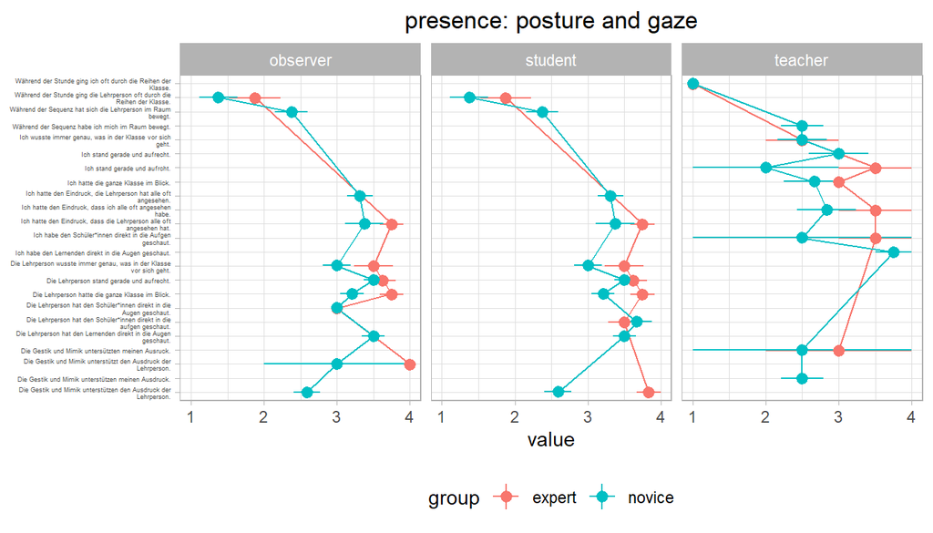

# References

Helmke, A., Helmke, T., Lenske, G., Pham, G., Praetorius, A. K., Schrader, F. W., & AdeThurow, M. (2014). Unterrichtsdiagnostik mit EMU. Aus-und Fortbildung der Lehrkräfte in Hinblick auf Verbesserung der Diagnosefähigkeit, Umgang mit Heterogenität und individuelle Förderung, 149-163.

R Core Team (2019). R: A language and environment for statistical computing. R Foundation for Statistical Computing, Vienna, Austria. URL https://www.R-project.org/.

Wickham et al., (2019). Welcome to the tidyverse. Journal of Open Source Software, 4(43), 1686, https://doi.org/10.21105/joss.01686